```python
from IPython.display import HTML
HTML('''<script>
code_show=true;
function code_toggle() {
  if (code_show){
    $(\'div.input\').hide();
  } else {
    $(\'div.input\').show();
  }
  code_show = !code_show
}
$( document ).ready(code_toggle);
</script>
  <form action="javascript:code_toggle()">
    <input type="submit" value="点击此处隐藏/显示代码.">
 </form>''')
```

淘宝用户行为数据分析  
*夏仔阳*  
2020-3-15

# 数据介绍和处理

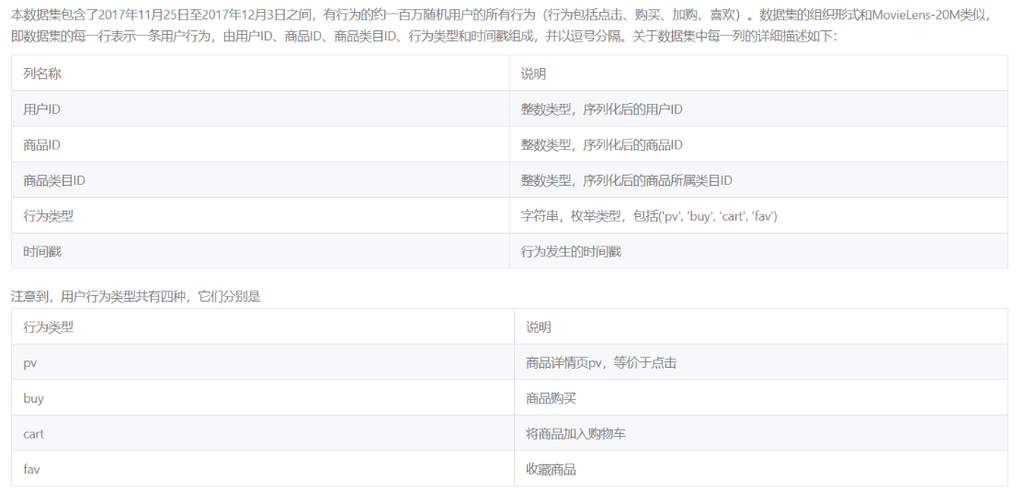

## 数据处理(时间转换,缺失值处理,异常值处理)

```python
%config InlineBackend.figure_format='retina'
import pandas as pd
import numpy as np
import warnings
import gc
warnings.filterwarnings('ignore')
```

```python
pd.set_option('float_format', lambda x: '%.6f' % x)
ogdata=pd.read_csv('UserBehavior.csv',header=None)
ogdata.columns=['User','Item','Category','Behavior','Date']
date=pd.to_datetime(ogdata['Date'].values,unit='s')
ogdata['Date']=date.date
ogdata['Time']=date.time
ogdata['year']=date.year
ogdata['Month']=date.month
ogdata['Day']=date.day
ogdata['Hour']=date.hour
ogdata['Week']=date.week
```

```python
ogdata.isnull().sum()
ogdata=ogdata.dropna(axis=0)
```

因为包含缺失值只有一条，所以选择直接去掉缺失值

```python
ogdata=ogdata.sort_values(by='Date',ascending=True)
ogdata=ogdata.reset_index(drop=True)
ogdata=ogdata.truncate(before=2,after=(3835329-17)).reset_index(drop=True)
ogdata.to_csv('Processed_UserBehavior.csv',index=False)
```

数据后17行和前2行为无意义数据或错误数据,在此删除  
接着把经过处理的数据保存为Processed_UserBehavior.csv

# 提出问题

1.分析用户在不同时间下的行为规律，探索用户在不同时间周期下的活跃规律  
2.分析用户对不同种类商品的偏好，找到针对不同商品的营销策略  
3.分析用户使用淘宝中的常见电商分析指标，确定各个环节的流失率，找到需要改进的环节  
4.分析用户结构，对不同用户进行价值分析

# 解决问题

## 用户在不同时间周期下的行为规律展示

### 一周中每天的用户行为

```python
data=pd.read_csv('Processed_UserBehavior.csv')
week=data.groupby(['Week','Day','Behavior']).count()['User']
week48=pd.pivot_table(week.loc[48,:].reset_index(),index=['Day'],values='User',columns='Behavior').reset_index()
week48['Day']=[5,6,7,1,2,3,4]
week48=week48.sort_values(by='Day').reset_index(drop=True)
```

```python
from pyecharts.charts import Bar
from pyecharts.charts import Line
from pyecharts.faker import Faker
from pyecharts import options as opts
from pyecharts.globals import ThemeType
line= (Line({"theme": ThemeType.SHINE}).add_xaxis(Faker.week).add_yaxis("浏览数", week48['pv'],yaxis_index=1)
       .extend_axis(yaxis=opts.AxisOpts(name='浏览数',axislabel_opts=opts.LabelOpts(formatter="{value}次")
        ))
        .set_global_opts( tooltip_opts=opts.TooltipOpts(
            is_show=True, trigger="axis", axis_pointer_type="cross"
        ),title_opts=opts.TitleOpts(title="第48周: 2017-11-27到2017-12-02"),
       legend_opts=opts.LegendOpts(pos_left='40%'),
      yaxis_opts=opts.AxisOpts(name="购买/收藏/加入购物车次数"
      ,axislabel_opts=opts.LabelOpts(formatter="{value}次")),
        xaxis_opts=opts.AxisOpts(name='时间',name_gap=30,name_location='start'))
)
bar=(Bar()
     .add_xaxis(Faker.week)
     .add_yaxis("购买",week48['buy'].tolist())
     .add_yaxis("收藏", week48['fav'].tolist())
     .add_yaxis("加入购物车",week48['cart'].tolist())
     .set_series_opts(
        label_opts=opts.LabelOpts(is_show=False))
 )
ove1=line.overlap(bar)
#line.render('第48周: 2017-11-27到2017-12-02.html')
ove1.render_notebook()
```

#### 结论

可以看到明显不同，**在工作日时各项指标平稳，而到周末有所上涨**，与常识相符，假日会有更多人有时间使用淘宝，因此**各种营销活动应该适当放到周末进行,也要考虑节日等因素**，才能取得更好的销量

### 一天中每小时的用户行为

```python
data_sat=data.groupby(['Date','Hour','Behavior']).count()['User'].loc['2017-12-02']
data_wed=data.groupby(['Date','Hour','Behavior']).count()['User'].loc['2017-11-29']
sat=pd.pivot_table(data_sat.reset_index(),index='Hour',columns='Behavior')
wed=pd.pivot_table(data_wed.reset_index(),index='Hour',columns='Behavior')
```

```python
from pyecharts.charts import Bar
from pyecharts.charts import Line
from pyecharts import options as opts
from pyecharts.globals import ThemeType
line= (Line({"theme": ThemeType.SHINE}).add_xaxis(wed.index.tolist()).add_yaxis("浏览数", wed[('User','pv')].tolist(),yaxis_index=1)
       .extend_axis(yaxis=opts.AxisOpts(name='浏览数',axislabel_opts=opts.LabelOpts(formatter="{value}次")
        ,interval=10000))
        .set_global_opts( datazoom_opts=opts.DataZoomOpts(type_="inside"),tooltip_opts=opts.TooltipOpts(
            is_show=True, trigger="axis", axis_pointer_type="cross"
        ),title_opts=opts.TitleOpts(title="2017-11-29(周三)"),
       legend_opts=opts.LegendOpts(pos_left='40%'),
      yaxis_opts=opts.AxisOpts(name="购买/收藏/加入购物车次数"
      ,axislabel_opts=opts.LabelOpts(formatter="{value}次")),
        xaxis_opts=opts.AxisOpts(name='时间',name_gap=30,name_location='start'))
)
bar=(Bar()
     .add_xaxis(wed.index.tolist())
     .add_yaxis("购买",wed[('User','buy')].tolist())
     .add_yaxis("收藏", wed[('User','fav')].tolist())
     .add_yaxis("加入购物车",wed[('User','cart')].tolist())
     .set_series_opts(
        label_opts=opts.LabelOpts(is_show=False))
 )
ove2=line.overlap(bar)
#line.render('2017-11-29(周三).html')
ove2.render_notebook()
```

```python
from pyecharts.charts import Bar
from pyecharts.charts import Line
from pyecharts import options as opts
from pyecharts.globals import ThemeType
line= (Line({"theme": ThemeType.SHINE}).add_xaxis(sat.index.tolist()).add_yaxis("浏览数", sat[('User','pv')].tolist(),yaxis_index=1)
       .extend_axis(yaxis=opts.AxisOpts(name='浏览数',axislabel_opts=opts.LabelOpts(formatter="{value}次")
        ,interval=10000))
        .set_global_opts( datazoom_opts=opts.DataZoomOpts(type_="inside"),tooltip_opts=opts.TooltipOpts(
            is_show=True, trigger="axis", axis_pointer_type="cross"
        ),title_opts=opts.TitleOpts(title="2017-12-02(周六)"),
       legend_opts=opts.LegendOpts(pos_left='40%'),
      yaxis_opts=opts.AxisOpts(name="购买/收藏/加入购物车次数"
      ,axislabel_opts=opts.LabelOpts(formatter="{value}次")),
        xaxis_opts=opts.AxisOpts(name='时间',name_gap=30,name_location='start'))
)
bar=(Bar()
     .add_xaxis(sat.index.tolist())
     .add_yaxis("购买",sat[('User','buy')].tolist())
     .add_yaxis("收藏", sat[('User','fav')].tolist())
     .add_yaxis("加入购物车",sat[('User','cart')].tolist())
     .set_series_opts(
        label_opts=opts.LabelOpts(is_show=False))
 )
ove3=line.overlap(bar)
#line.render('2017-12-02(周六).html')
ove3.render_notebook()
```

#### 结论

可以看出**两天中用户行为规律十分相似**，无论是浏览,加入购物车,收藏,购买都是在午间达到峰值。  
**但是这里与常识习惯不符，常识习惯这个峰值应当在傍晚到来，符合大部分人的作息时间**。经过一些调查，排除了一下外在客观原因(节日之类的)，**认为应当是数据集统计不够完整。所以无法得出有效的结论**。

## 用户对不同商品的偏好展示

### 观察浏览，收藏，加入购物车和购买的次数分布

```python
pp=data.groupby(['Item','Behavior']).count()['User'].reset_index()
trans=pd.pivot_table(pp,index='Item',columns='Behavior')
pv=trans['User']['pv'].reset_index()
pv_num=pv['pv'].value_counts().sort_index()[:25].reset_index()#浏览次数分布
buy=trans['User']['buy'].reset_index()
buy_num=buy['buy'].value_counts().sort_index()[:25].reset_index()#购买次数分布
cart=trans['User']['cart'].reset_index()
cart_num=cart['cart'].value_counts().sort_index()[:25].reset_index()#加入购物车次数分布
fav=trans['User']['fav'].reset_index()
fav_num=fav['fav'].value_counts().sort_index()[:25].reset_index()#收藏次数分布
```

```python
from pyecharts.charts import Line
from pyecharts import options as opts
from pyecharts.globals import ThemeType
line1= (Line({"theme": ThemeType.WONDERLAND})
       .add_xaxis(pv_num['index'])
       .add_yaxis("浏览", pv_num['pv'])
       .add_yaxis("收藏", fav_num['fav'])
       .add_yaxis("加入购物车", cart_num['cart'])
       .add_yaxis("购买", buy_num['buy'])
        .set_global_opts(datazoom_opts=opts.DataZoomOpts(type_="inside"),tooltip_opts=opts.TooltipOpts(
            is_show=True, trigger="axis", axis_pointer_type="cross"),
        title_opts=opts.TitleOpts(title="浏览，收藏，加入购物车和购买的次数分布")
       ,legend_opts=opts.LegendOpts(pos_left='40%'),
      yaxis_opts=opts.AxisOpts(axislabel_opts=opts.LabelOpts(formatter="{value}人")),
        xaxis_opts=opts.AxisOpts(name='/ 次',min_=0))
       .set_series_opts(label_opts=opts.LabelOpts(is_show=True))
)
#line.render('用户行为次数分布.html')
line1.render_notebook()
```

根据本次分析的数据，**只购买一次的商品有45910种**，**购买两次的商品有6989种**,而购买商品种类有56726种,**购买1-2次的商品占了商品总类的93.3%。且在购买，在浏览，收藏，加入购物车都存在此种现象。**  
这说明**商品售卖主要依靠长尾商品的累计效应，而不是爆款商品的带动。**

```python
numbers=data.groupby(['Item','Behavior']).count()['User'].reset_index()
trans=pd.pivot_table(numbers,index='Item',columns='Behavior')
pv=trans.sort_values(by=[('User','pv')],ascending=False)
pv_20=pv['User']['pv'][:10].reset_index()
pv_20.set_index('Item',inplace=True) #浏览前20
buy=trans.sort_values(by=[('User','buy')],ascending=False)
buy_20=buy['User']['buy'][:10].reset_index()
buy_20.set_index('Item',inplace=True) #销量前20
fav=trans.sort_values(by=[('User','fav')],ascending=False)
fav_20=fav['User']['fav'][:10].reset_index()
fav_20.set_index('Item',inplace=True) #收藏前20
cart=trans.sort_values(by=[('User','cart')],ascending=False)
cart_20=cart['User']['cart'][:10].reset_index()
cart_20.set_index('Item',inplace=True) #购物车前20
```

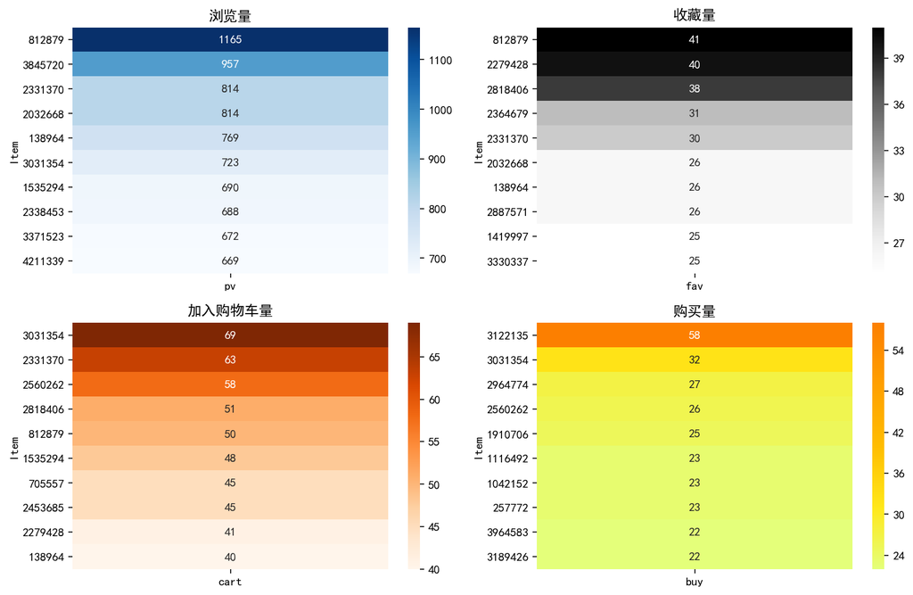

```python
%config InlineBackend.figure_format='retina'
import seaborn as sns
import matplotlib.pyplot as plt
plt.rcParams['font.sans-serif']=['SimHei']
plt.style.use('fast')
fig=plt.figure(figsize=(11,7))
ax1=plt.subplot(221)
sns.heatmap(pv_20,annot=True,fmt='.20g',cmap=plt.cm.Blues)
plt.title('浏览量')
ax2=plt.subplot(222)
sns.heatmap(fav_20,annot=True,cmap=plt.cm.Greys)
plt.title('收藏量')
ax3=plt.subplot(223)
sns.heatmap(cart_20,annot=True,cmap=plt.cm.Oranges)
plt.title('加入购物车量')
ax4=plt.subplot(224)
sns.heatmap(buy_20,annot=True,cmap=plt.cm.Wistia)
plt.title('购买量')
plt.tight_layout()
plt.show()
#fig.savefig('用户对不同商品的偏好展示.png',dpi=300)
```

### 用户对不同商品偏好的结论

在购买量前10的的商品中只有1个浏览量前10的商品，而在收藏量前10中却有4个位于浏览量前10的商品，这说明这些**吸引了用户注意力的商品并不能直接转化为销量，而是更多的被收藏**。  
加入购物车和购买的重复商品有2件，这说明**加入购物车比浏览转化成实际销量的可能性更大(符合常识)** 而收藏和购买没有重复的商品，这说明**加入收藏之后大概率不会再购买**。  
针对浏览量高而销量不高的这部分商品，需要提高的是用户从点击进入商品详情页到最终购买的体验。作为商家端可以从以下几个方面提高销售额：  
（1） 商品详情页的实际价格是否相比展示价格偏差过大，杜绝商家为了吸引用户点击在商品展示页投放的价格与实际价格不符，在用户心中反而引起抗拒心理。  
（2）同时也要杜绝商家在商品首页大搞噱头而与实际商品质量或观感不同的行为。  
（3）对收藏进行优化，定期提醒用户收藏内的商品，以免用户在加入收藏后对之抛掷脑后。  
（4）优化商品展示的形式，利用视频等方式给用户更直观的感受，提高照片的美观程度。

## 基于AARRR的漏斗模型分析用户转化率

```python
total_times=data['Behavior'].value_counts().reset_index()
aa=data.groupby(['Behavior','User']).count()['Item'].reset_index()
aa.set_index('Behavior',inplace=True)
buy_ppe=aa.loc['buy',:].shape[0]
cart_ppe=aa.loc['cart',:].shape[0]
fav_ppe=aa.loc['fav',:].shape[0]
pv_ppe=aa.loc['pv',:].shape[0]
total_ppe=[pv_ppe,cart_ppe,fav_ppe,buy_ppe]
```

```python
from pyecharts.charts import Bar
from pyecharts import options as opts
from pyecharts.globals import ThemeType
bar1=(Bar({"theme": ThemeType.WESTEROS})
     .add_xaxis(total_times['index'].tolist())
    .add_yaxis("总次数", total_times['Behavior'].tolist(),stack="stack1")
     .add_yaxis("总人数",total_ppe,stack="stack1")
     .set_series_opts(
        label_opts=opts.LabelOpts(is_show=False))
     .set_global_opts(datazoom_opts=opts.DataZoomOpts(type_="inside"),tooltip_opts=opts.TooltipOpts(
            is_show=True, trigger="axis", axis_pointer_type="cross"),
        title_opts=opts.TitleOpts(title='用户行为次数和用户数对比'))
    )
#bar.render('用户行为次数和用户数对比.html')
bar1.render_notebook()
```

可以看出平均每人的各项指标都很高，这说明**淘宝的用户粘性是比较高的**，每位用户为淘宝的行为记录的贡献都是比较多的。

```python
from pyecharts import options as opts
from pyecharts.charts import Funnel,Page
from pyecharts.faker import Faker
from pyecharts.globals import ThemeType
behavior=['浏览','加入购物车','收藏','购买']
c1 = (
    Funnel({"theme": ThemeType.SHINE})
    .add("用户行为数", [list(z) for z in zip(behavior,total_times['Behavior'].tolist())])
    .set_global_opts(title_opts=opts.TitleOpts(title="用户行为次数",subtitle='转化率图'))
)
c2= (
    Funnel({"theme": ThemeType.SHINE})
    .add("用户数", [list(z) for z in zip(behavior,total_ppe)]
         ,label_opts=opts.LabelOpts(position="inside"))
    .set_global_opts(title_opts=opts.TitleOpts(title="用户数",subtitle='转化率图'))
)
page1=Page().add(c2).add(c1)
page1.render_notebook()
#page.render('AARRR转化率探索.html')
```

1. 从用户数转化中可以明显看出漏斗的坡度很低，即从浏览到购买的用户数量流失率并不大，这说明淘宝的PUR比较高。购买过商品的用户占到了统计用户总体的**68%**，同时这也符合常识。  
   同时购买的用户多于收藏这也同时说明了之前提到的:**多数用户在加入收藏之后大概率不会再购买此商品了**这一结论。
2. 从用户行为次数转化图中可以看出，在浏览向下的转化的流失率是非常大的，浏览这一行为占到了总行为数量的**90%**。这说明**无目的地随便看看可能是用户使用淘宝的主要模式**。

### 基于AARRR理论分析结论

1. 获取用户:  
   由于没有用户首次登陆的时间，因此默认所有用户都为首次登陆的新用户。  
   这里新用户一共有**37376名**
2. 激活用户:  
   由于数据时间跨度不够完整，因此这里将各种行为次数在50次以上用户定义为活跃。  
   活跃用户一共有**25054**名，活跃用户比例占**67%**  
   用户从点击、放进购物车、收藏以及购买，由于收藏和加入购物车都为浏览和购买阶段之间确定购买意向的用户行为，因此将其算作一个阶段，而从**买前阶段到购买行为的行为转化率只有2%。** **而从买前阶段到有购买行为的客户数转化率达到32%**，当然有一部分用户是直接购买，所以为了进一步提高这一转化率，特别是针对行为转化率可以：  
   （1）优化电商平台的搜索匹配度和推荐策略，主动根据用户喜好推荐相关的商品，提升用户的购买欲。  
   （2）对于再收藏中放置时间比较定期像客户发送提醒，防止用户将商品放入收藏之后就抛之脑后。  
   （3）优化加入购物车的体验，简化步骤的同时提升用户的预购买满足感(比如加一些动效等等)
3. 提高留存率  
   数据中只有1名用户再首次登陆后再未进行过登录，这说明淘宝的用户留存率是很高的
4. 获取收入  
   可以看出淘宝的PUC非常高,达到了**68%**。想要进一步扩大购买用户占比则应当增加从买前阶段到购买行为的行为转化率， 比如 : (1) 对付费意愿低的用户可以推荐性价比的商品 （2）对付费意愿低的用户可以进行促销活动，发放代金券等
5. 用户推荐: 鉴于淘宝的用户普及程度，这里认为对于一二线城市推广可以减少，转而对三四线城市可以加大推广力度，例如和三四线城市的实体店进行合作扩大用户范围。

## 基于RFM建立用户价值评估模型

### R值计算

有购买行为用户一共有**25400**人，由于数据集不够完整 **(购买记录只有2017-11-24到2017-12-03), 其中有8688人只进行过一次购买记录无法得到最近一次和上一次的时间间隔，所以将这部分人均匀分配到各个时间间隔**，所有购买用户的R值分布如图

```python
data=pd.read_csv('Processed_UserBehavior.csv')
buy_table=data[data['Behavior']=='buy']
buy_per=buy_table['User'].value_counts().reset_index()#购买总用户
many_buy=buy_per[buy_per['User']!=1]#多次购买
one_buy=buy_per[buy_per['User']==1]#一次购买
cc=buy_table[buy_table['User'].isin(many_buy['index'])] #cc:多次购买的用户的购买记录表
cc=cc.sort_values(by=['User','Date'])
R=cc[['User','Date']]
last=R.drop_duplicates(subset='User', keep='last', inplace=False)
last_time=last.reset_index(drop=True)#最近一次
last2_time=R.drop(index=last.index).drop_duplicates(subset='User', keep='last', inplace=False)#前一次
last2_time=last2_time.reset_index(drop=True)
Diff=pd.to_datetime(last_time['Date'])-pd.to_datetime(last2_time['Date'])
```

```python
def Avg_distribution(df):
    dfed=df
    x=dfed.shape[0]
    begin=0
    for i in range(9):
        dfed.iloc[begin:begin+x//10,1]=i
        begin+=(x//10)
    return dfed
bb=buy_table[buy_table['User'].isin(one_buy['index'])]
bb['Diff']=9
one_buy_users=bb[['User','Diff']]
one_buy_users=Avg_distribution(one_buy_users)#把只有一次购买用户均匀分配到其他所有间隔上
diff=pd.DataFrame({'User':last2_time['User'],'Diff':Diff})
diff['Diff']=diff['Diff'].map(lambda x:x.days)
diff_table=pd.concat([one_buy_users,diff]).rename(columns={'Diff':'Diff(days)'}).sort_values(by='Diff(days)',ascending=True)
diff_table=diff_table.reset_index(drop=True)#所有用户的R值表
```

```python
pic_table=(diff_table['Diff(days)'].value_counts().reset_index()
.rename(columns={'index':'Days','Diff(days)':'counts'})
.sort_values(by='Days'))
from pyecharts.charts import Bar
from pyecharts import options as opts
from pyecharts.globals import ThemeType
bar2=(Bar({"theme": ThemeType.LIGHT})
     .add_xaxis(pic_table['Days'].tolist())
     .add_yaxis("用户数",pic_table['counts'].tolist())
     .set_series_opts(
        label_opts=opts.LabelOpts(is_show=True))
     .set_global_opts(datazoom_opts=opts.DataZoomOpts(type_="inside"),tooltip_opts=opts.TooltipOpts(
            is_show=True, trigger="axis", axis_pointer_type="cross"),
        yaxis_opts=opts.AxisOpts(axislabel_opts=opts.LabelOpts(formatter="{value}人")),
        xaxis_opts=opts.AxisOpts(axislabel_opts=opts.LabelOpts(formatter="{value}天")),
        title_opts=opts.TitleOpts(title='用户最近一次消费间隔分布',subtitle='鼠标滚轮放大'))
    )
#bar.render('用户最近一次消费间隔分布.html')
bar2.render_notebook()
```

### F值计算

F值是用户在固定时间内的购买次数，由于数据集时间跨度较小，因此计算用户的所有购买次数做F值

```python
freq_table=buy_table.groupby('User').count()['Item'].reset_index().rename(columns={'Item':'Frequency'})
pic_table=freq_table['Frequency'].value_counts().reset_index().sort_values(by='index')
pic_table=pic_table.rename(columns={'index':'Frequency','Frequency':'counts'})
from pyecharts.charts import Bar
from pyecharts import options as opts
from pyecharts.globals import ThemeType
bar3=(Bar({"theme": ThemeType.WONDERLAND})
     .add_xaxis(pic_table['Frequency'].tolist())
     .add_yaxis("用户数",pic_table['counts'].tolist())
     .set_series_opts(
        label_opts=opts.LabelOpts(is_show=True))
     .set_global_opts(datazoom_opts=opts.DataZoomOpts(type_="inside"),tooltip_opts=opts.TooltipOpts(
            is_show=True, trigger="axis", axis_pointer_type="cross"),
        yaxis_opts=opts.AxisOpts(axislabel_opts=opts.LabelOpts(formatter="{value}人")),
        xaxis_opts=opts.AxisOpts(axislabel_opts=opts.LabelOpts(formatter="{value}次")),
        title_opts=opts.TitleOpts(title='用户消费频率',subtitle='鼠标滚轮放大'))
    )
#bar.render('用户消费频率.html')
bar3.render_notebook()
```

### M值计算

由于没有商品的单价信息，无法计算M值

### 用户评估分数

- R(评分) :  
  统计的时间跨度在9天，因此R值的分数可以用10减去时间间隔，即两次购买间隔为0天的用户为10分，间隔1天为9分**间隔越大分数越低，最低为1分。**
- F(评分) :  
  购买次数在1-9次得1分，10-19次得2分，20-29次得3分，30-39次得4分，40-49得5分，50次以上得6分
- M(评分) :  
  由于没有商品的单价信息，**无法计算M值，所以都当作0。**
- 总分 :  
  由于时间跨度比较小，**即使R评分为9分即用户每天最少都购买一次也有可能只购买了9次。所以这里我认为结合数据集来看R评分的重要程度＜F评分的重要程度。因此设置F评分占总分权重60%,R评分占40%。**

```python
def change(x):
    if x<=9:return 1
    if 10<=x<=19:return 2
    if 20<=x<=29:return 3
    if 30<=x<=39:return 4
    if 40<=x<=49:return 5
    if x>=50:return 6
diff_table['R']=10-diff_table['Diff(days)']
R_table=diff_table[['User','R']].sort_values(by='User').reset_index(drop=True)
R_table
freq_table['F']=freq_table['Frequency'].map(change)
F_table=freq_table[['User','F']].sort_values(by='User').reset_index(drop=True)
score_table=pd.concat([R_table,F_table['F']],axis=1)
score_table["score"]=score_table['R']*0.4+score_table['F']*0.6
score_table=score_table.sort_values(by='score',ascending=False).reset_index(drop=True)
```

```python
from pyecharts.components import Table
from pyecharts.options import ComponentTitleOpts
table = Table()
headers = score_table.columns.tolist()
rows = score_table[:15].values
table.add(headers, rows)
table.set_global_opts(
    title_opts=ComponentTitleOpts(title="评分前15用户", subtitle="score为综合R和F的最终评分")
)
table.render_notebook()
```

评分前15用户

score为综合R和F的最终评分

| User | R | F | score |
| --- | --- | --- | --- |
| 107932.0 | 10.0 | 6.0 | 7.6 |
| 1008380.0 | 10.0 | 6.0 | 7.6 |
| 242650.0 | 10.0 | 6.0 | 7.6 |
| 128379.0 | 10.0 | 6.0 | 7.6 |
| 234304.0 | 10.0 | 6.0 | 7.6 |
| 190873.0 | 10.0 | 6.0 | 7.6 |
| 122504.0 | 10.0 | 6.0 | 7.6 |
| 165222.0 | 10.0 | 6.0 | 7.6 |
| 158803.0 | 10.0 | 5.0 | 7.0 |
| 1003983.0 | 10.0 | 5.0 | 7.0 |
| 140047.0 | 10.0 | 5.0 | 7.0 |
| 221096.0 | 10.0 | 4.0 | 6.4 |
| 172091.0 | 10.0 | 4.0 | 6.4 |
| 253135.0 | 10.0 | 4.0 | 6.4 |
| 16907.0 | 10.0 | 4.0 | 6.4 |

### 用户分类

根据评分将用户分为四类

- 1类：潜在用户(score<=1.8)
- 2类：活跃用户(1.8<score<=3.6)
- 3类：成熟用户(3.6<score<=5)
- 4类：核心用户(score>=5)

```python
pie_table=score_table.copy()
def map_class(x):
    if x<=1.8: return '1'
    if 1.8<x<=3.6: return '2'
    if 3.6<x<=5: return '3'
    if x>=5: return '4'
pie_table['class']=pie_table['score'].apply(map_class)
pie_pic=pie_table['class'].value_counts().reset_index()
pie_pic=pie_pic.sort_values(by='index')
```

```python
from pyecharts import options as opts
from pyecharts.charts import Pie
from pyecharts.globals import ThemeType
user=['1.潜在用户','2.活跃用户','3.成熟用户','4.核心用户']

p1=(
    Pie({'theme':ThemeType.WONDERLAND})
    .add("",[list(z)for z in zip(user,pie_pic['class'].tolist())],center=["40%", "50%"],radius=["40%", "70%"])
    .set_global_opts(
        title_opts=opts.TitleOpts(title="不同用户分布"),
        legend_opts=opts.LegendOpts(pos_left="80%", orient="vertical"))
    .set_series_opts(tooltip_opts=opts.TooltipOpts(trigger="item", formatter="{c}人 ({d}%)"))
)
#p1.render('不同用户分布.html')
p1.render_notebook()
```

## 结论

综合评分越高的用户是体系中的越有价值用户，对于不同类型的用户需要采取不同的策略。  
对于潜在用户，运营活动可以重点针对这部分用户，可以通过拼团打折、积分兑换等活动唤起用户购买欲望。  
对于活跃和成熟用户则应用更稳健的手段，以优化用户使用体验为主，辅助以一定的个性化推送提醒。  
对于核心客户需要给予一定的关注，可以设置专门的反馈渠道进一步优化这类用户的体验。

```python
from pyecharts.charts import Funnel,Page
page=(Page(layout=Page.DraggablePageLayout).add(ove1).add(ove2).add(ove3).add(line1).add(bar1).add(c1).add(c2)
.add(bar2).add(bar3).add(table).add(p1)
     )
#page.render("淘宝分析.html")
#Page.save_resize_html("淘宝用户行为分析.html", cfg_file="chart_config (2).json",dest="淘宝用户行为分析.html")
```

[output not shown]